# Assessment: Predicting Weight Lifting Excercises

Make42

# Abstract / Executive Summary

The goal of this work is to do a prediction on a weightlifting dataset.

For more information see the paper “Qualitative Activity Recognition of Weight Lifting Exercises” from Velloso et al. at http://perceptual.mpi-inf.mpg.de/files/2013/03/velloso13_ah.pdf

# Cross-Validation

In order to valididate the results later on, we devide the set into a training and a testing dataset. I used the function `createDataPartition()` on the variable `classe` with 75% of the data in the training set.

Therefore we have three datasets: The labeled training dataset, the labeled testing dataset (of which both come from the orginal provided training data, which has 19622 observations in total) and the unlabeled testing dataset which is our new data we want to predict, which has only 20 observations in total.

# Feature Selection

After examining the data it became quickly obvious that a feature selection was necessary.

## Get rid of NA and irrelevant Features

In the dataset there were a lot of values that were completely not available in the unlabeled new data of 20 observations. Therefore those variables could not be used in the prediction and where discarded. The reason is that those variables are derived features derived from examining sliding windows. However the unlabeled test data do not have any kind of window variables - the prediction has to take place on a single observation.

Also discarded where irrelevant feature, as for example IDs or timestamps.

## Near Zero Variance

During the feature selection I took a closer look at Near Zero Variance with the function `nearZeroVar()`. The following plot shows “frequency ratio” and “percent of unique values” for each feature.

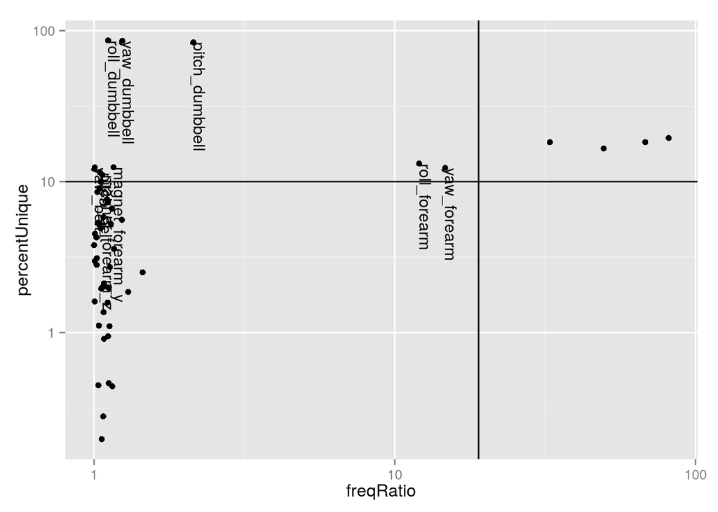

## Correlation

Also considered was the correlation of the features. The following plot shows a histogram of the correlation values. For the plot, the absolutes of the values in the upper triangle of the correlation matrix where used.

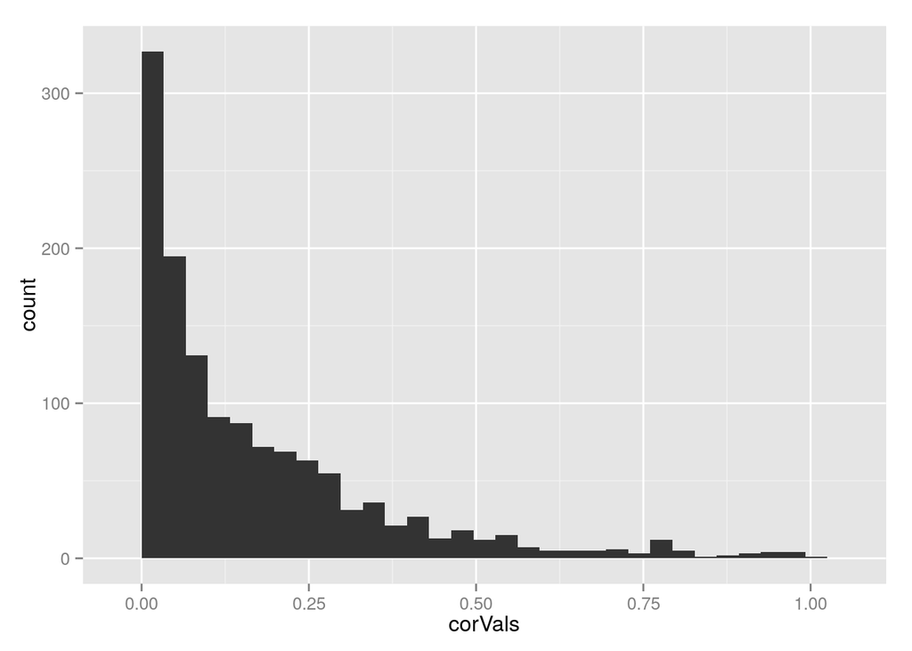

## Feature analysis and selection

The diagnostics frequency ratio, percent of unique values and the correlation where used in order to assess the features:

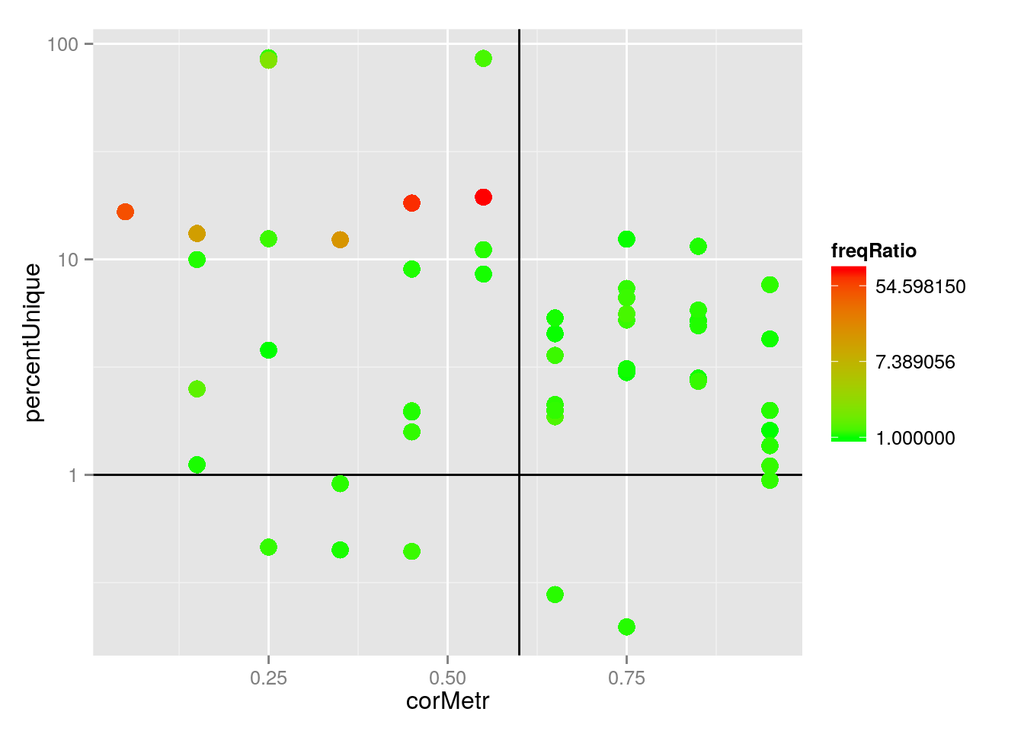

From this the features with frequency ratio smaller 7, percent of unique values greater 1 and correlation smaller than 0.6 where choosen.

Those relevant feature are

```
##  [1] "gyros_belt_z"     "magnet_belt_y"    "gyros_arm_y"
##  [4] "gyros_arm_z"      "magnet_arm_x"     "magnet_arm_z"
##  [7] "roll_dumbbell"    "pitch_dumbbell"   "yaw_dumbbell"
## [10] "gyros_forearm_x"  "gyros_forearm_y"  "accel_forearm_z"
## [13] "magnet_forearm_x" "magnet_forearm_y" "magnet_forearm_z"
```

# Training

For the training a decision tree was used, which was trained on the labeled training data. The decision tree is

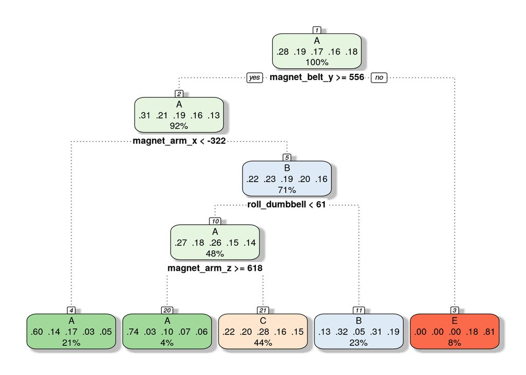

# Results

The results are shown in the following confidence matrices.

For the labeled training data:

```
## Confusion Matrix and Statistics
##
##           Reference
## Prediction    A    B    C    D    E
##          A 2326  462  586  141  198
##          B  433 1112  183 1065  658
##          C 1423 1271 1796 1009  948
##          D    0    0    0    0    0
##          E    3    3    2  197  902
##
## Overall Statistics
##
##                Accuracy : 0.4169
##                  95% CI : (0.4089, 0.4249)
##     No Information Rate : 0.2843
##     P-Value [Acc > NIR] : < 2.2e-16
##
##                   Kappa : 0.2644
##  Mcnemar's Test P-Value : < 2.2e-16
##
## Statistics by Class:
##
##                      Class: A Class: B Class: C Class: D Class: E
## Sensitivity            0.5558  0.39045   0.6996   0.0000  0.33333
## Specificity            0.8683  0.80295   0.6172   1.0000  0.98293
## Pos Pred Value         0.6264  0.32223   0.2786      NaN  0.81481
## Neg Pred Value         0.8311  0.84592   0.9068   0.8361  0.86746
## Prevalence             0.2843  0.19350   0.1744   0.1639  0.18386
## Detection Rate         0.1580  0.07555   0.1220   0.0000  0.06129
## Detection Prevalence   0.2523  0.23447   0.4380   0.0000  0.07521
## Balanced Accuracy      0.7121  0.59670   0.6584   0.5000  0.65813
```

For the labeled testing data:

```
## Confusion Matrix and Statistics
##
##           Reference
## Prediction   A   B   C   D   E
##          A 768 150 205  41  63
##          B 150 362  71 357 206
##          C 477 436 579 337 344
##          D   0   0   0   0   0
##          E   0   1   0  69 288
##
## Overall Statistics
##
##                Accuracy : 0.4072
##                  95% CI : (0.3934, 0.4211)
##     No Information Rate : 0.2845
##     P-Value [Acc > NIR] : < 2.2e-16
##
##                   Kappa : 0.2524
##  Mcnemar's Test P-Value : < 2.2e-16
##
## Statistics by Class:
##
##                      Class: A Class: B Class: C Class: D Class: E
## Sensitivity            0.5505  0.38145   0.6772   0.0000  0.31964
## Specificity            0.8692  0.80177   0.6063   1.0000  0.98251
## Pos Pred Value         0.6259  0.31588   0.2665      NaN  0.80447
## Neg Pred Value         0.8295  0.84380   0.8989   0.8361  0.86516
## Prevalence             0.2845  0.19352   0.1743   0.1639  0.18373
## Detection Rate         0.1566  0.07382   0.1181   0.0000  0.05873
## Detection Prevalence   0.2502  0.23369   0.4431   0.0000  0.07300
## Balanced Accuracy      0.7099  0.59161   0.6418   0.5000  0.65108
```

[figure not shown]

Unfortunately, the results are not very impressive.

# Prediction of new data

The prediction for the 20 unlabeled new observations are

```
##  [1] A A C A C B C C A A B C C A C A A B C A
## Levels: A B C D E
```

# Conclusion

It is easy to see that the results are not very impressive. I guess the reason lies in the choice of the features. Maybe other methods of finding the right features should be used or derived features build. I am looking forward to suggestions on this part.